# Proyecto - Contingencias de Vida I

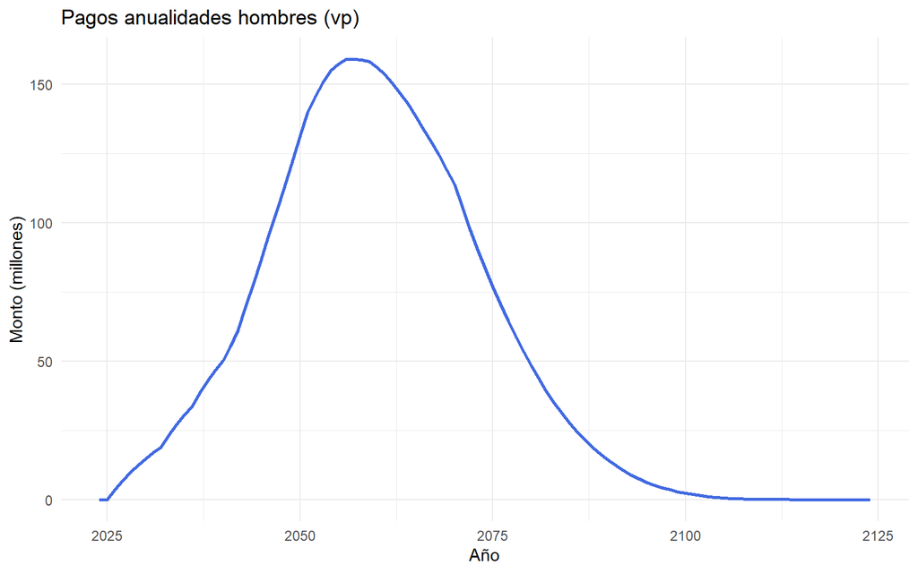

```r
ggplot() +
  geom_line(data = proy_H_fin,
            aes(x = Año, y = proy_ann_vp/1000000, color = "hombres"),
            size = 1) +
  scale_color_manual(
    values = c(
      "hombres" = "royalblue"
    )
  ) +
  labs(
    x = "Año",
    y = "Monto (millones)",
    title = "Pagos anualidades hombres (vp)",
    color = "Sexo"
  ) +
  theme_minimal() +
  theme(legend.position = 'none')
```

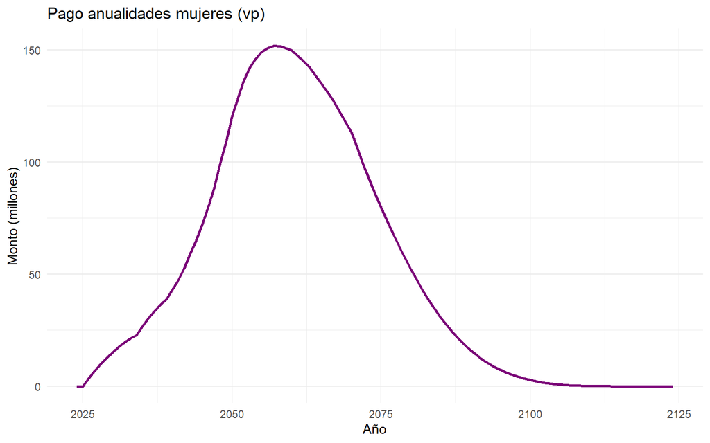

[figure not shown]

```r
ggplot() +
  geom_line(data = proy_M_fin,
            aes(x = Año, y = proy_ann_vp/1000000, color = "mujeres"),
            size = 1) +
  scale_color_manual(
    values = c(
      "mujeres" = "#7a0177"
    )
  ) +
  labs(
    x = "Año",
    y = "Monto (millones)",
    title = "Pago anualidades mujeres (vp)",
    color = "Sexo"
  ) +
  theme_minimal() +
  theme(legend.position = "none")
```

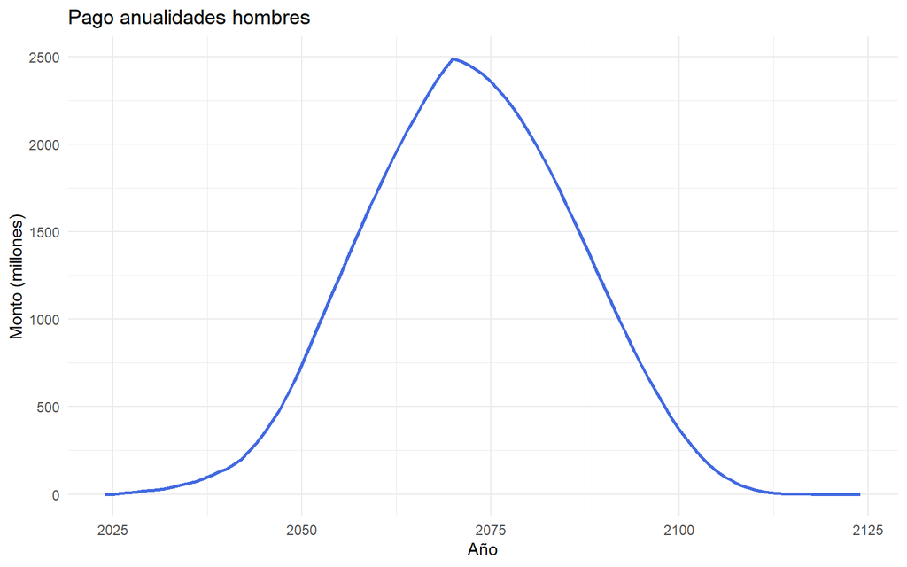

```r
ggplot() +
  geom_line(data = proy_H_fin,
            aes(x = Año, y = proy_ann_fin/1000000, color = "hombres"),
            size = 1) +
  scale_color_manual(
    values = c(
      "hombres" = "royalblue"
    )
  ) +
  labs(
    x = "Año",
    y = "Monto (millones)",
    title = "Pago anualidades hombres",
    color = "Sexo"
  ) +
  theme_minimal() +
  theme(legend.position = 'none')
```

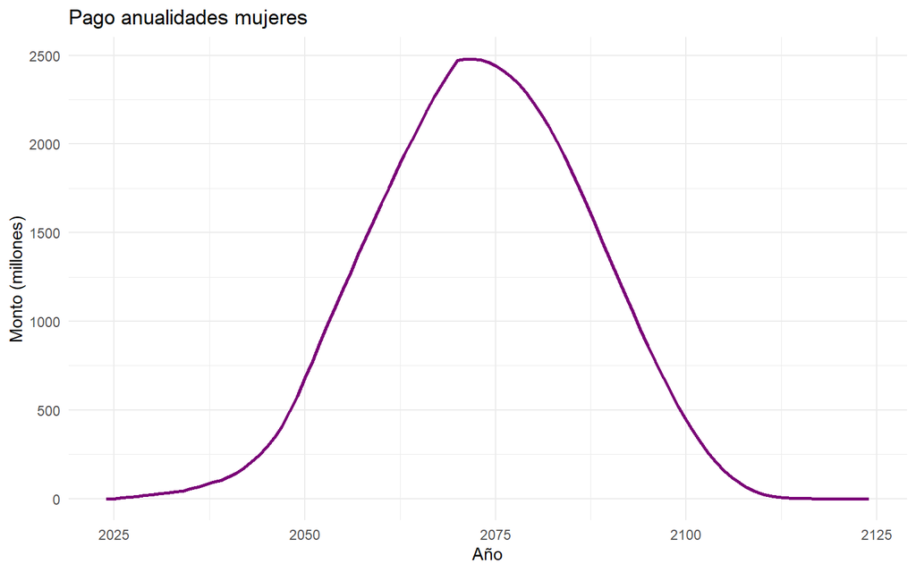

[figure not shown]

```r
ggplot() +
  geom_line(data = proy_M_fin,
            aes(x = Año, y = proy_ann_fin/1000000, color = "mujeres"),
            size = 1) +
  scale_color_manual(
    values = c(
      "mujeres" = "#7a0177"
    )
  ) +
  labs(
    x = "Año",
    y = "Monto (millones)",
    title = "Pago anualidades mujeres",
    color = "Sexo"
  ) +
  theme_minimal() +
  theme(legend.position = "none")
```

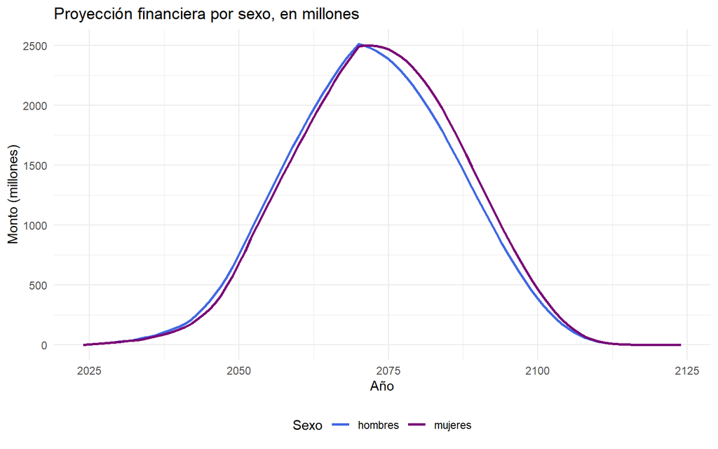

```r
ggplot() +
  geom_line(data = proy_hombres,
            aes(x = año, y = valor_fin/1000000, color = "hombres"),
            size = 1) +
  geom_line(data = proy_mujeres,
            aes(x = año, y = valor_fin/1000000, color = "mujeres"),
            size = 1) +
  scale_color_manual(
    values = c(
      "hombres" = "royalblue",
      "mujeres" = "#7a0177"
    )
  ) +
  labs(
    x = "Año",
    y = "Monto (millones)",
    title = "Proyección financiera por sexo, en millones",
    color = "Sexo"
  ) +
  theme_minimal() +
  theme(legend.position = 'bottom')
```

Este comportamiento se da porque primero los hombres se mueren más temprano, entonces esos 5 millones evalúan más la remuneración. Pasado ese punto, aproximadamente 45 años, entonces ya no existe esa remuneración, por la cual la pensión tomará peso y por lo tanto costará más pagarle a las mujeres.

```r
rm(proy_ann_fin)
rm(proy_ann_vp)
rm(proy_emp_fin)
rm(proy_emp_vp)
rm(proy_pen_fin)
rm(proy_pen_vp)
rm(proy_H_fin)
rm(proy_M_fin)
```

# Prima anual

## Función de la prima

Va a servir para la nivelada

```r
#' Calcula la prima anual para los empleados de ABC
#' @param df Recibe el df de probabilidades de sobrevivencia de las personas de ABC
#' @return Devuelve un data frame con edad, sexo, la prima anual y el vp de las obligaciones de la empresa con la persona.
primas <- function(qx){
  c <- 1
  df = data.frame(edad = numeric(500), sexo = numeric(500), prima = numeric(500))

  #Se itera sobre las personas
  for (i in 1:500){
    x <- qx[[i]]

    if(i != 1) {
      ant <-qx[[i-1]]
      if((x[[2]] == ant[[2]]) & (x[[3]] == ant[[3]])){
        df[c,] <-df[c-1,]
        c <- c+1
        next
      }
    }
    vp_pen <- 0
    px_acum <- 1
    ann_primas<-0
    #Iteramos sobre la cantidad de años posibles de la persona x
    for (j in 1:length(x[[1]])) {
      # 1) cálculo de los 1M en caso de muerte del pensionado
      # 2) cálculo de los 5M en caso de muerte del empleado
      # 3) cálculo de la pensión
      # 4) cálculo de la anualidad para las primas

      # Si la persona tiene menos de 65 calculamos el seguro de empleado activo y la prima
      if (j + x[[3]] <= 65){
        # Cálculo de las anualidades de primas
        ann_primas<-ann_primas + px_acum*(1.03/1.07)^(j-1)

        # Calculamos el vp del seguro de empleado activo
        vp_pen <- vp_pen + px_acum *(1 - x[[1]][[j]])*5000000*(1.03/1.07)^(j-1)
      } else {
        #Si tiene mas de 65 le calculamos la pensión y el seguro de muerte de pensionado


        interes <- 1.07^(1/12) - 1
        # se hace el supuesto que paga la primera pensión al final de mes
        VP_ann <- 300000*(1-(1/1.07))/interes
        VP_agui <- 300000*(1/1.07) # modificación - aguinaldo a final de año
        VP <- VP_ann + VP_agui
        vp_pen <- vp_pen + px_acum *(1 - x[[1]][[j]])*1000000*(1.03/1.07)^(j-1)
        k <- 1/(1+interes) # V mensual
        acum <- 0
        # Caso muerte en un mes predeterminado
        for(m in 1:11){
          acum <- acum + (12 - m)*300000*m*px_acum *(1 - x[[1]][[j]])*k^m/12
        }

        # Se suman los valores presentes por el caso de que viva o muera
        vp_pen <- vp_pen +
          (acum + (px_acum *(x[[1]][[j]] + (1 - x[[1]][[j]])/12))*VP)*(1.03/1.07)^(j-1)
      }

      # Actualiza la probabilidad acumulada
      px_acum <- px_acum *(x[[1]][[j]])


    }
    # Almacena los resultados en el dataframe
    df$edad[c] <- x[[3]]
    df$sexo[c] <- x[[2]]
    df$vp[c] <- vp_pen
    df$anualidad[c] <- ann_primas
    df$prima[c] <- vp_pen/ann_primas
    c <- c+1
  }
  return(df)
}


primas_anuales <- primas(qx)
primas_anuales <- primas_anuales %>% arrange(edad) %>% distinct()
```

## Resumir la prima anual

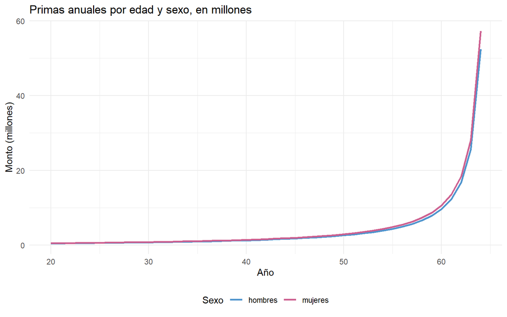

```r
ggplot() +
  geom_line(data = primas_anuales[primas_anuales$sexo == 1,],
            aes(x = edad, y = prima/1000000, color = "hombres"),
            size = 1) +
  geom_line(data = primas_anuales[primas_anuales$sexo == 2,],
            aes(x = edad, y = prima/1000000, color = "mujeres"),
            size = 1) +
  scale_color_manual(
    values = c(
      "hombres" = "steelblue3",
      "mujeres" = "hotpink3"
    )
  ) +
  labs(
    x = "Año",
    y = "Monto (millones)",
    title = "Primas anuales por edad y sexo, en millones",
    color = "Sexo"
  ) +
  theme_minimal() +
  theme(legend.position = 'bottom')
```

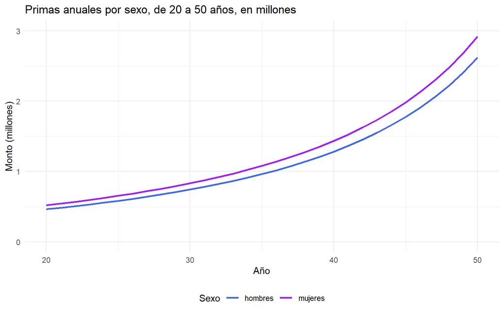

```r
ggplot() +
  geom_line(data = primas_anuales[primas_anuales$sexo == 1,],
            aes(x = edad, y = prima/1000000, color = "hombres"),
            size = 1) +
  geom_line(data = primas_anuales[primas_anuales$sexo == 2,],
            aes(x = edad, y = prima/1000000, color = "mujeres"),
            size = 1) +
  scale_color_manual(
    values = c(
      "hombres" = "royalblue",
      "mujeres" = "purple"
    )
  ) +
  labs(
    x = "Año",
    y = "Monto (millones)",
    title = "Primas anuales por sexo, de 20 a 50 años, en millones",
    color = "Sexo"
  ) +
  theme_minimal() +
  theme(legend.position = 'bottom') +
  xlim(20,50) +
  ylim(0, 3)
```

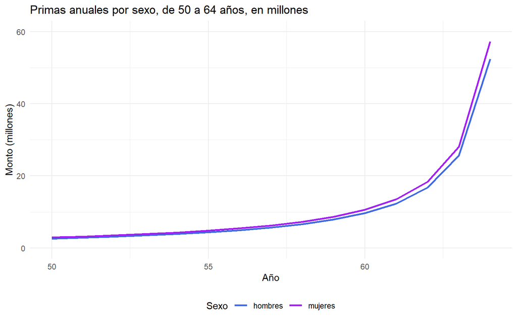

```r
ggplot() +
  geom_line(data = primas_anuales[primas_anuales$sexo == 1,],
            aes(x = edad, y = prima/1000000, color = "hombres"),
            size = 1) +
  geom_line(data = primas_anuales[primas_anuales$sexo == 2,],
            aes(x = edad, y = prima/1000000, color = "mujeres"),
            size = 1) +
  scale_color_manual(
    values = c(
      "hombres" = "royalblue",
      "mujeres" = "purple"
    )
  ) +
  labs(
    x = "Año",
    y = "Monto (millones)",
    title = "Primas anuales por sexo, de 50 a 64 años, en millones",
    color = "Sexo"
  ) +
  theme_minimal() +
  theme(legend.position = 'bottom') +
  xlim(50,64) +
  ylim(0, 60)
```

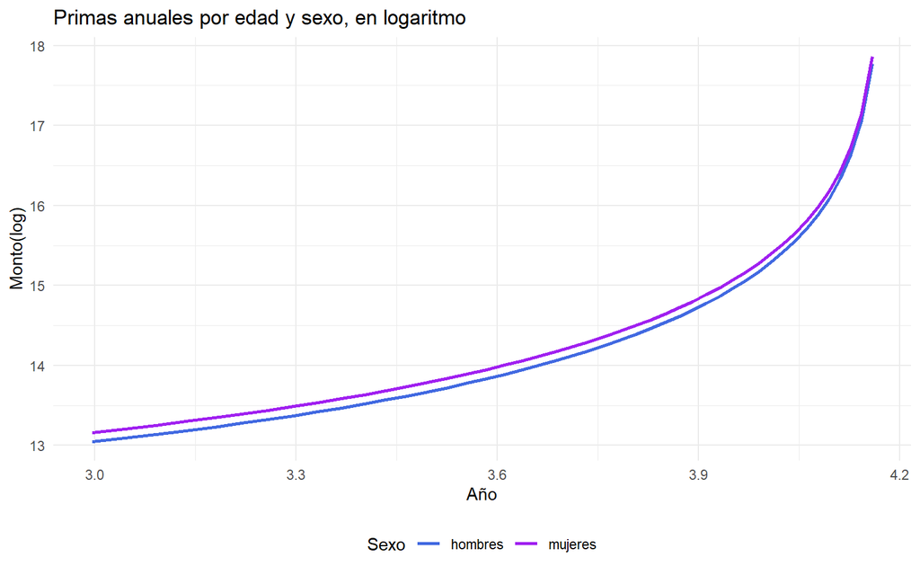

```r
ggplot() +
  geom_line(data = log(primas_anuales[primas_anuales$sexo == 1,]),
            aes(x = edad, y = prima, color = "hombres"),
            size = 1) +
  geom_line(data = log(primas_anuales[primas_anuales$sexo == 2,]),
            aes(x = edad, y = prima, color = "mujeres"),
            size = 1) +
  scale_color_manual(
    values = c(
      "hombres" = "royalblue",
      "mujeres" = "purple"
    )
  ) +
  labs(
    x = "Año",
    y = "Monto(log)",
    title = "Primas anuales por edad y sexo, en logaritmo",
    color = "Sexo"
  ) +
  theme_minimal() +
  theme(legend.position = 'bottom')
```

# Prima nivelada

## Suma de los valores presentes

```r
#Sumamos toda las obligaciones de la empresa en su valor presente
(suma_vp <- sum(proy_hombres$valor_p) + sum(proy_mujeres$valor_p) )
```

```
## [1] 10518874294
```

```r
(suma_check <- sum(primas(qx)$vp))
```

```
## [1] 10518874294
```

```r
(resta<-suma_vp-suma_check)
```

```
## [1] 0.03501892
```

## Cálculo de la prima

```r
(prima_nivelada <- suma_vp/sum(primas(qx)$anualidad))
```

```
## [1] 1275281
```

La prima nivelada entonces da 1.28 millones de colones anuales aproximadamente, o 106 mil colones al mes.

# Prueba de métodos diferentes

## Modificación de la función primas

```r
#' Calcula el valor financiero del año de las obligaciones por anualidades de los pensionados
#'
#' @param qx Recibe el dataframe que contiene la probabilidad de supervivencia, edad y sexo para cada individuo
#' @param m_p Monto de la pensión mensual
#' @param m_me Monto en caso de muerte antes de los 65 años
#' @param m_mp Monto en caso de muerte después de los 65 años
#' @return Devuelve un dataframe con la edad, sexo, valor presente, anualidad y prima para cada individuo
primas_esp <- function(qx, m_p, m_me, m_mp){
  # Inicializa el contador y el dataframe de resultados
  c <- 1
  df = data.frame(edad = numeric(500), sexo = numeric(500), prima = numeric(500))
  # Itera sobre cada elemento en la lista qx
  for (i in 1:500){
    x <- qx[[i]]
    # Verifica si el elemento actual es igual al anterior
    if(i != 1) {
      ant <-qx[[i-1]]
      if((x[[2]] == ant[[2]]) & (x[[3]] == ant[[3]])){
        # Si es igual, copia los valores del anterior y pasa al siguiente
        df[c,] <-df[c-1,]
        c <- c+1
        next
      }
    }
    # Inicializa el valor presente de las pensiones y la probabilidad acumulada
    vp_pen <- 0
    px_acum <- 1
    ann_primas <- 0
    # Itera sobre cada año para calcular el valor presente de las pensiones
    for (j in 1:length(x[[1]])) {
      vp_pen <- vp_pen
      # Cálculo del valor presente de las pensiones en caso de muerte antes y después de los 65
      if (j + x[[3]] <= 65){
        ann_primas <- ann_primas + px_acum*(1.03/1.07)^(j-1)
        vp_pen <- vp_pen + px_acum *(1 - x[[1]][[j]])*m_me*(1.03/1.07)^(j-1)
      } else {
        interes <- 1.07^(1/12) - 1
        # Valor presente de las anualidades y aguinaldo
        VP_ann <- m_p*(1-(1/1.07))/interes
        VP_agui <- m_p*(1/1.07)
        VP <- VP_ann + VP_agui
        vp_pen <- vp_pen + px_acum *(1 - x[[1]][[j]])*m_mp*(1.03/1.07)^(j-1)
        k <- 1/(1+interes)
        acum <- 0
        # Caso muerte en un mes predeterminado
        for(m in 1:11){
          acum <- acum + (12 - m)*m_p*m*px_acum *(1 - x[[1]][[j]])*k^m/12
        }

        vp_pen <- vp_pen +
          (acum + (px_acum *(x[[1]][[j]] + (1 - x[[1]][[j]])/12))*VP)*(1.03/1.07)^(j-1)
      }
      # Actualiza la probabilidad acumulada
      px_acum <- px_acum *(x[[1]][[j]])


    }

    # Almacena los resultados en el dataframe
    df$edad[c] <- x[[3]]
    df$sexo[c] <- x[[2]]
    df$vp[c] <- vp_pen
    df$anualidad[c] <- ann_primas
    df$prima[c] <- vp_pen/ann_primas
    c <- c+1
  }
  return(df)
}
```

```r
(sum(primas_esp(qx, 300000, 5000000, 1000000)$vp))
```

```
## [1] 10518874294
```

```r
metodo0 <- primas_esp(qx, 300000, 5000000, 1000000)$prima
```

## Método 1

Para la reducción de las primas, tendremos que comparar entre métodos. Por ejemplo, propongamos en reducir la pensión lo necesario, usando aproximación manual

```r
metodo1 <- primas_esp(qx, 269181, 5000000, 1000000)$prima
sum(metodo1/metodo0 <=0.9)/length(metodo0) # si da 1, todos coinciden
```

```
## [1] 1
```

```r
mean(metodo1/metodo0) # esta cantidad es para resumir, se cumple lo de arriba
```

```
## [1] 0.8990323
```

## Método 2

Ahora bien, reduzca aún más el monto de la pensión, pero duplique los otros montos

```r
metodo2 <- primas_esp(qx, 261000, 10000000, 2000000)$prima # dio cerrado
sum(metodo2/metodo0 <=0.9)/length(metodo0)
```

```
## [1] 1
```

```r
mean(metodo2/metodo0)
```

```
## [1] 0.8893845
```

## Métodos alternativos

Observe que la diferencia es muy poca, las mortalidades de empleados y pensionados aportan muy poco. Reducir estas a 0 no influye mucho

```r
mean(primas_esp(qx, 300000, 0, 0)$prima/metodo0)
```

```
## [1] 0.9828456
```

Entonces una opción sería aumentar más o igualar los montos de muerte

```r
metodo3 <- primas_esp(qx, 250104, 7500000, 7500000)$prima
sum(metodo3/metodo0 <=0.9)/length(metodo0)
```

```
## [1] 1
```

```r
mean(metodo3/metodo0)
```

```
## [1] 0.8876222
```

```r
metodo4 <- primas_esp(qx, 207552, 30000000, 15000000)$prima
sum(metodo4/metodo0 <=0.9)/length(metodo0)
```

```
## [1] 1
```

```r
mean(metodo4/metodo0)
```

```
## [1] 0.8466662
```

```r
rm(metodo0)
rm(metodo1)
rm(metodo2)
rm(metodo3)
rm(metodo4)
rm(primas_esp)
rm(suma_check)
rm(suma_vp)
rm(prima_nivelada)
rm(primas)
```

# Modelo estocástico

Para la construcción de un modelo estocástico ocuparemos:

1. las probabilidades de muerte (qx)
2. las personas, dadas por runif
3. Pagar los montos respectivos, dependiendo de la muerte o no

## Preparativos para acelerar el proceso

```r
lista_90 <- data.frame(Edad = primas_anuales$edad, Sexo = primas_anuales$sexo)
qx_unicos <- get_qx(lista_90, SUPEN_num)
anualidades <- primas_anuales$anualidad
edades <- numeric(90)
sexo <- numeric(90)
for (c in 1:90){
  edades[c] <- qx_unicos[[c]][[3]]
  sexo[c] <- qx_unicos[[c]][[2]]
}
k <- 1/(1.07^(1/12))
VP <- (300000*(1-(1/1.07)))/(1.07^(1/12) - 1) + 300000*(1/1.07) # modificación - aguinaldo a final de año)
eval <- (1.03/1.07)^(1:96)
```

## Creando la función de simulación

```r
#' Realiza una simulación del valor presente de las pensiones de forma estocástica
#'
#' @param df Recibe un dataframe que contiene la probabilidad de supervivencia, edad y sexo para cada individuo
#' @return Devuelve un dataframe con las primas calculadas para cada individuo
simulacion <- function(df){
  len <- length(df)
  # Inicializa los vectores para contar los vivos, las pensiones y la suma del valor presente
  vivos <- numeric(len) + 1
  pen <- numeric(len)
  suma_vp <- numeric(len)
  # Itera sobre cada uno de los períodos
  for (i in 1:96){
    # Calcula el factor de descuento para el período actual
    dif <- eval[i]
    # Itera sobre cada individuo en el dataframe
    for (c in 1:len){
      # Si el individuo ya está muerto o no hay más datos de probabilidad, pasa al siguiente
      if(vivos[c] == 0 | i > length(df[[c]][[1]])){
        next
      }

      # Si la edad del individuo más el período actual es mayor a 65, se le otorga pensión
      if(df[[c]][[3]] + i > 65){
        pen[c] <- 1
      }

      # Si el individuo está vivo, realiza una simulación de muerte
      if(vivos[c] == 1){
        if(runif(1) > df[[c]][[1]][[i]]){
          vivos[c] <- 0
          # Calcula el valor presente en caso de muerte, dependiendo de si tenía pensión o no
          if(pen[c] == 1){
            suma_vp[c] <- suma_vp[c] + 1000000*dif
            mes <- floor(12*runif(1))+1
            if(mes != 12){
              suma_vp[c] <- suma_vp[c] + (12 - mes)*300000*mes*dif*k^mes/12
            } else {
              suma_vp[c] <- suma_vp[c] + pen[c]*vivos[c]*VP*dif/12
            }
          } else {
            suma_vp[c] <- suma_vp[c] + 5000000*dif
          }
        }
      }



      # Suma el valor presente de las pensiones en caso de que el individuo siga vivo
      suma_vp[c] <- suma_vp[c] + pen[c]*vivos[c]*VP*dif
    }
  }

  # Calcula las primas dividiendo la suma del valor presente por las anualidades
  df <- data.frame(prima = suma_vp/anualidades)

  return(df[[1]])
}
```

```r
t <- proc.time()
una <- simulacion(qx_unicos)
proc.time() - t
```

```
##    user  system elapsed
##    0.05    0.00    0.05
```

## Las simulaciones

La función dura 30 min, o 26 min aproximadamente

```r
# t <- proc.time()
# simulaciones <- list()
# for(i in 1:100000){
#   if(i %% 1000 == 0){
#     print(i)
#   }
#   simulaciones[[i]] <- simulacion(qx_unicos)
# }
# proc.time() - t
```

## Proceder a escribir la data para guardarla

```r
# datos_sim <- data.frame(primas_anuales[,1:2], simulaciones)
# names(datos_sim) <- c("edad", "sexo", 1:100000)
# write.csv(datos_sim,"res/simulaciones.csv")
```

## Revertir el cambio e importar los datos

```r
datos_sim <- read_csv("res/simulaciones.csv", show_col_types = FALSE) %>% select(-`...1`)
```

## Cálculo de percentiles

```r
t <- proc.time()
percentiles <- data.frame(primas_anuales[,1:2])
for (i in 1:90){
  temp <- as.numeric(datos_sim[i,3:100002])
  percentiles$per_50[i] <- quantile(temp, 0.5)
  percentiles$per_90[i] <- quantile(temp, 0.9)
}
proc.time() - t
```

```
##    user  system elapsed
##   28.59    0.06   29.07
```

```r
rm(eval)
rm(c)
rm(una)
rm(i)
rm(get_qx)
rm(simulacion)
rm(VP)
rm(t)
rm(sexo)
rm(edades)
rm(anualidades)
rm(lista_90)
rm(temp)
rm(k)
```

# Comparación de primas

```r
primas_finales <- primas_anuales[,1:3]
primas_finales$per_50 <- percentiles$per_50
primas_finales$per_90 <- percentiles$per_90
```

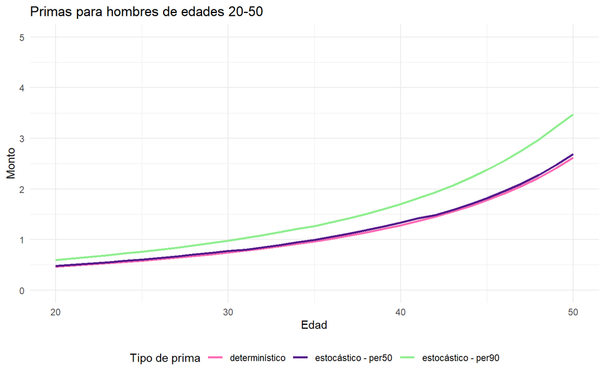

```r
ggplot() +
  geom_line(data = primas_finales[primas_finales$sexo == 1,],
            aes(x = edad, y = prima/1000000, color = "determinístico"),
            size = 1) +
  geom_line(data = primas_finales[primas_finales$sexo == 1,],
            aes(x = edad, y = per_50/1000000, color = "estocástico - per50"),
            size = 1) +
  geom_line(data = primas_finales[primas_finales$sexo == 1,],
          aes(x = edad, y = per_90/1000000, color = "estocástico - per90"),
          size = 1) +
  scale_color_manual(
    values = c(
      "determinístico" = "hotpink",
      "estocástico - per50" = "purple4",
      "estocástico - per90" = "lightgreen"
    )
  ) +
  labs(
    x = "Edad",
    y = "Monto",
    title = "Primas para hombres de edades 20-50",
    color = "Tipo de prima"
  ) +
  theme_minimal() +
  theme(legend.position = 'bottom') +
  xlim(20,50) +
  ylim(0,5)
```

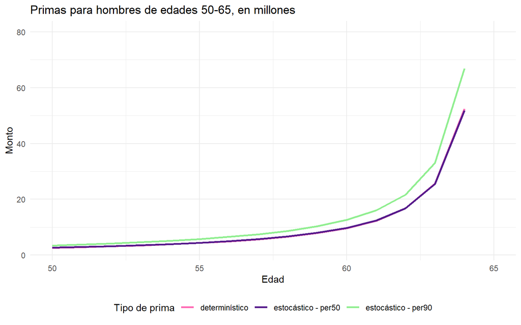

```r
ggplot() +
  geom_line(data = primas_finales[primas_finales$sexo == 1,],
            aes(x = edad, y = prima/1000000, color = "determinístico"),
            size = 1) +
  geom_line(data = primas_finales[primas_finales$sexo == 1,],
            aes(x = edad, y = per_50/1000000, color = "estocástico - per50"),
            size = 1) +
  geom_line(data = primas_finales[primas_finales$sexo == 1,],
          aes(x = edad, y = per_90/1000000, color = "estocástico - per90"),
          size = 1) +
  scale_color_manual(
    values = c(
      "determinístico" = "hotpink",
      "estocástico - per50" = "purple4",
      "estocástico - per90" = "lightgreen"
    )
  ) +
  labs(
    x = "Edad",
    y = "Monto",
    title = "Primas para hombres de edades 50-65, en millones",
    color = "Tipo de prima"
  ) +
  theme_minimal() +
  theme(legend.position = 'bottom') +
  xlim(50,65) +
  ylim(2,80)
```

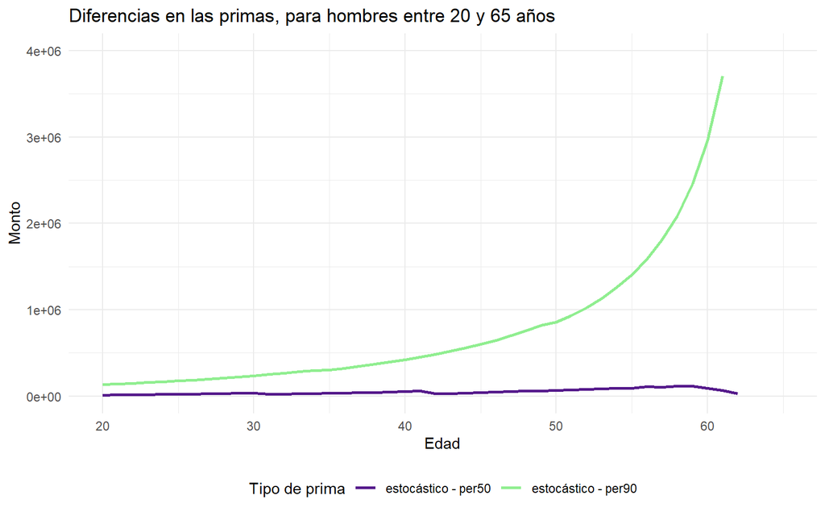

```r
ggplot() +
  geom_line(data = primas_finales[primas_finales$sexo == 1,],
            aes(x = edad, y = per_90 - prima, color = "estocástico - per90"),
            size = 1) +
  geom_line(data = primas_finales[primas_finales$sexo == 1,],
            aes(x = edad, y = per_50 - prima, color = "estocástico - per50"),
            size = 1) +
  scale_color_manual(
    values = c(
      "estocástico - per90" = "lightgreen",
      "estocástico - per50" = "purple4"
    )
  ) +
  labs(
    x = "Edad",
    y = "Monto",
    title = "Diferencias en las primas, para hombres entre 20 y 65 años",
    color = "Tipo de prima"
  ) +
  theme_minimal() +
  theme(legend.position = 'bottom') +
  xlim(20,65) +
  ylim(0,4000000)
```

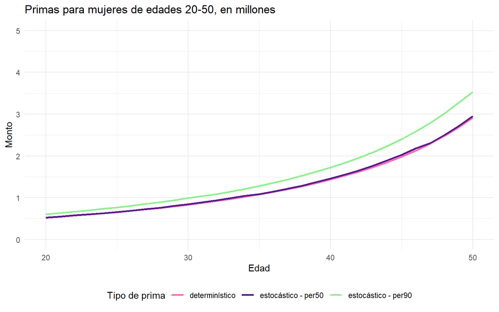

```r
ggplot() +
  geom_line(data = primas_finales[primas_finales$sexo == 2,],
            aes(x = edad, y = prima/1000000, color = "determinístico"),
            size = 1) +
  geom_line(data = primas_finales[primas_finales$sexo == 2,],
            aes(x = edad, y = per_50/1000000, color = "estocástico - per50"),
            size = 1) +
  geom_line(data = primas_finales[primas_finales$sexo == 2,],
          aes(x = edad, y = per_90/1000000, color = "estocástico - per90"),
          size = 1) +
  scale_color_manual(
    values = c(
      "determinístico" = "hotpink",
      "estocástico - per50" = "purple4",
      "estocástico - per90" = "lightgreen"
    )
  ) +
  labs(
    x = "Edad",
    y = "Monto",
    title = "Primas para mujeres de edades 20-50, en millones",
    color = "Tipo de prima"
  ) +
  theme_minimal() +
  theme(legend.position = 'bottom') +
  xlim(20,50) +
  ylim(0,5)
```

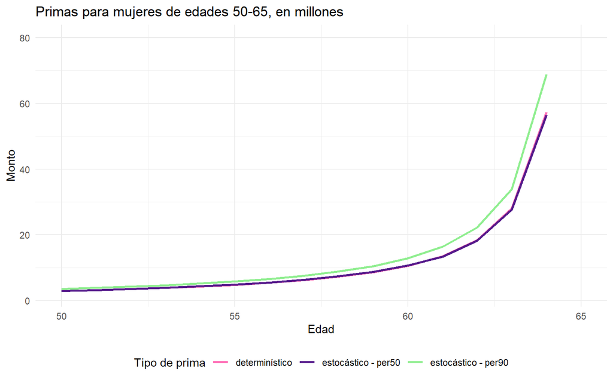

```r
ggplot() +
  geom_line(data = primas_finales[primas_finales$sexo == 2,],
            aes(x = edad, y = prima/1000000, color = "determinístico"),
            size = 1) +
  geom_line(data = primas_finales[primas_finales$sexo == 2,],
            aes(x = edad, y = per_50/1000000, color = "estocástico - per50"),
            size = 1) +
  geom_line(data = primas_finales[primas_finales$sexo == 2,],
          aes(x = edad, y = per_90/1000000, color = "estocástico - per90"),
          size = 1) +
  scale_color_manual(
    values = c(
      "determinístico" = "hotpink",
      "estocástico - per50" = "purple4",
      "estocástico - per90" = "lightgreen"
    )
  ) +
  labs(
    x = "Edad",
    y = "Monto",
    title = "Primas para mujeres de edades 50-65, en millones",
    color = "Tipo de prima"
  ) +
  theme_minimal() +
  theme(legend.position = 'bottom') +
  xlim(50,65) +
  ylim(2,80)
```

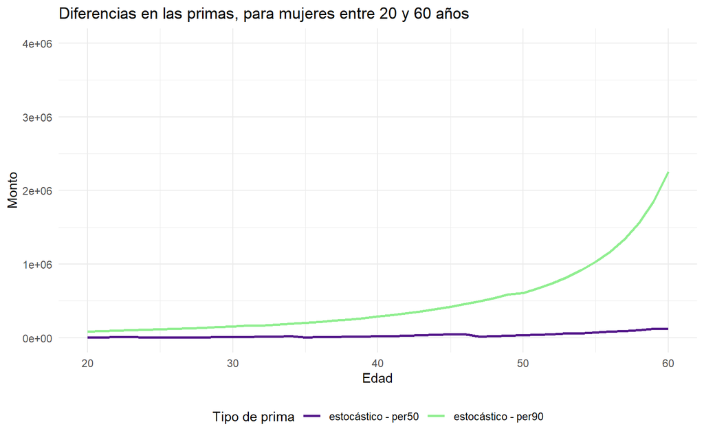

```r
ggplot() +
  geom_line(data = primas_finales[primas_finales$sexo == 2,],
            aes(x = edad, y = per_90 - prima, color = "estocástico - per90"),
            size = 1) +
  geom_line(data = primas_finales[primas_finales$sexo == 2,],
            aes(x = edad, y = per_50 - prima, color = "estocástico - per50"),
            size = 1) +
  scale_color_manual(
    values = c(
      "estocástico - per90" = "lightgreen",
      "estocástico - per50" = "purple4"
    )
  ) +
  labs(
    x = "Edad",
    y = "Monto",
    title = "Diferencias en las primas, para mujeres entre 20 y 60 años",
    color = "Tipo de prima"
  ) +
  theme_minimal() +
  theme(legend.position = 'bottom') +
  xlim(20,60) +
  ylim(0,4000000)
```